# Clase 9. Tests no paramétricos.

#### **1. Cargar paquetes.**

```r
# Instalar paquetes nuevos (solo la primera vez)
install.packages("dunn.test")
install.packages("palmerpenguins")
```

```r
library(tidyverse)
library(readxl)
library(dunn.test)
library(palmerpenguins)
```

#### **2. Tests paramétricos y no paramétricos.**

Hasta ahora hemos utilizado pruebas estadísticas **paramétricas** (test t, ANOVA), que asumen que los datos siguen una distribución normal. Sin embargo, en arqueología frecuentemente trabajamos con muestras pequeñas o datos que no cumplen este supuesto. En esos casos debemos recurrir a pruebas **no paramétricas**, que no asumen ninguna distribución particular.

Para decidir qué test usar, primero evaluamos la normalidad de los datos con el **test de Shapiro-Wilk** (`shapiro.test()`). La lógica es:

- Si **p > 0.05** → los datos distribuyen normal → usamos test paramétrico (t test o ANOVA).
- Si **p < 0.05** → los datos **no** distribuyen normal → usamos test no paramétrico.

Los equivalentes no paramétricos son:

| Situación | Paramétrico | No paramétrico |
| --- | --- | --- |
| Comparar 2 grupos | t test | Mann-Whitney (`wilcox.test`) |
| Comparar 3+ grupos | ANOVA | Kruskal-Wallis (`kruskal.test`) + Dunn (`dunn.test`) |

#### **3. Ejercicio 1: Dieta de camélidos en Tarapacá 40 y Caleta Vítor.**

Evaluamos si existen diferencias en los isótopos de nitrógeno (δ15N) entre camélidos del sitio interior Tarapacá 40 (Tr40) y el sitio costero Caleta Vítor (CV).

##### **3.1. Importar y explorar los datos.**

```r
camelidos_sitios <- read_excel("~/Desktop/work/0_Cuantitativa_2026/ANT305Q-2026/Clases/Clase9/Comparacion_Tr40_CV.xlsx")
camelidos_sitios
```

```
## # A tibble: 49 × 2
##    Sitio  d15N
##    <chr> <dbl>
##  1 Tr40    4.3
##  2 Tr40    5.2
##  3 Tr40    5.9
##  4 Tr40    6.2
##  5 Tr40    7.1
##  6 Tr40    7.1
##  7 Tr40    7.2
##  8 Tr40    7.4
##  9 Tr40    7.4
## 10 Tr40    7.7
## # ℹ 39 more rows
```

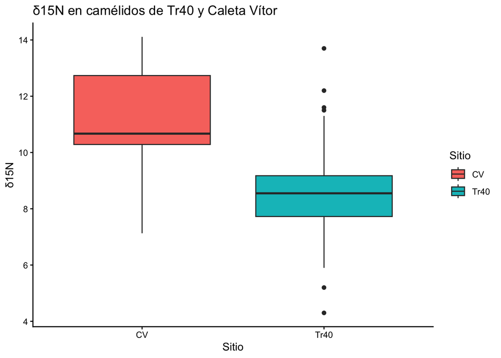

```r
ggplot(data = camelidos_sitios, aes(x = Sitio, y = d15N, fill = Sitio)) +
  geom_boxplot() +
  labs(x = "Sitio", y = "δ15N", title = "δ15N en camélidos de Tr40 y Caleta Vítor") +
  theme_classic()
```

##### **3.2. Test de normalidad Shapiro-Wilk.**

```r
shapiro.test(camelidos_sitios$d15N)
```

```
##
##  Shapiro-Wilk normality test
##
## data:  camelidos_sitios$d15N
## W = 0.97177, p-value = 0.2845
```

El valor p es mayor a 0.05, por lo que los datos distribuyen normal. Procedemos con un test t.

##### **3.3. Test t.**

```r
t.test(d15N ~ Sitio, data = camelidos_sitios)
```

```
##
##  Welch Two Sample t-test
##
## data:  d15N by Sitio
## t = 3.7675, df = 15.248, p-value = 0.001815
## alternative hypothesis: true difference in means between group CV and group Tr40 is not equal to 0
## 95 percent confidence interval:
##  1.104413 3.972716
## sample estimates:
##   mean in group CV mean in group Tr40
##          11.149091           8.610526
```

##### **3.4. Interpretación.**

¿Podemos rechazar la hipótesis nula? ¿Existen diferencias significativas en la dieta de los camélidos entre ambos sitios? ¿A qué podría deberse esto?

#### **4. Ejercicio 2: Largo de maíces en Tarapacá.**

Evaluamos si existen diferencias en el largo de los maíces entre los sitios TR40 y TR49.

##### **4.1. Importar y explorar los datos.**

```r
maices <- read_excel("~/Desktop/work/0_Cuantitativa_2026/ANT305Q-2026/Clases/Clase9/Largo_maices.xlsx")
maices
```

```
## # A tibble: 111 × 2
##    Sitio Largo
##    <chr> <dbl>
##  1 TR49    444
##  2 TR49    440
##  3 TR49    435
##  4 TR49    425
##  5 TR49    420
##  6 TR49    417
##  7 TR49    416
##  8 TR49    415
##  9 TR49    414
## 10 TR49    413
## # ℹ 101 more rows
```

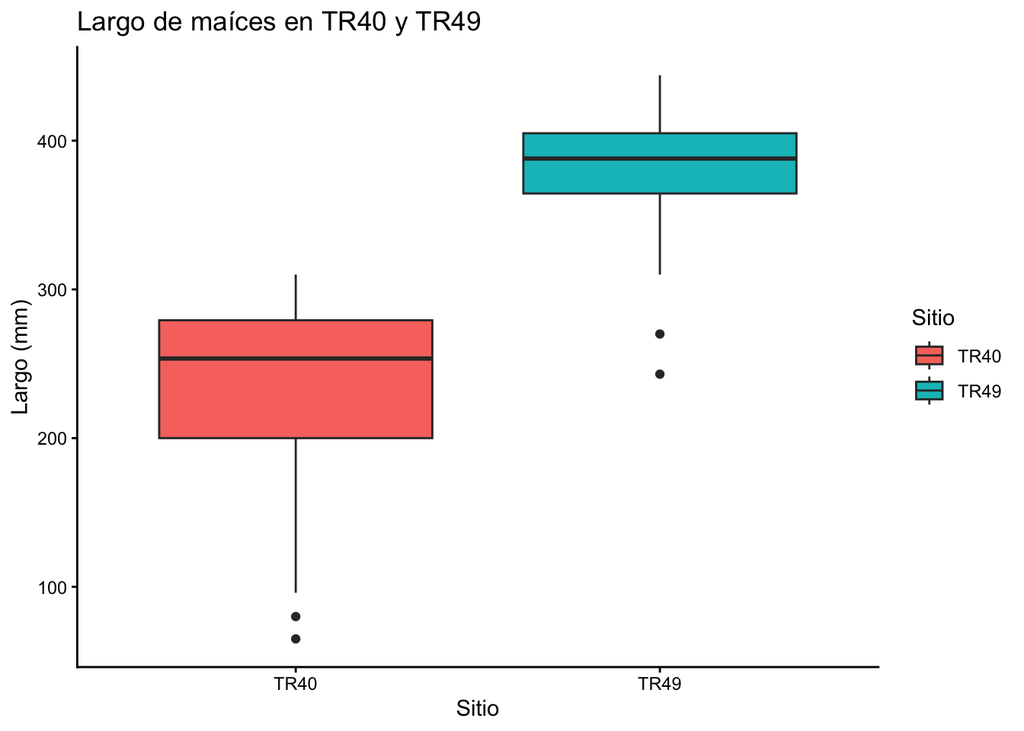

```r
ggplot(data = maices, aes(x = Sitio, y = Largo, fill = Sitio)) +
  geom_boxplot() +
  labs(x = "Sitio", y = "Largo (mm)", title = "Largo de maíces en TR40 y TR49") +
  theme_classic()
```

##### **4.2. Test de normalidad Shapiro-Wilk.**

```r
shapiro.test(maices$Largo)
```

```
##
##  Shapiro-Wilk normality test
##
## data:  maices$Largo
## W = 0.94954, p-value = 0.0003639
```

El valor p es menor a 0.05, por lo que los datos **no** distribuyen normal. Debemos usar un test no paramétrico para dos grupos independientes: el test de Mann-Whitney (`wilcox.test`).

##### **4.3. Test de Mann-Whitney.**

```r
wilcox.test(Largo ~ Sitio, data = maices)
```

```
##
##  Wilcoxon rank sum test with continuity correction
##
## data:  Largo by Sitio
## W = 56.5, p-value < 2.2e-16
## alternative hypothesis: true location shift is not equal to 0
```

##### **4.4. Interpretación.**

¿Podemos rechazar la hipótesis nula? ¿Existen diferencias significativas en el largo de los maíces entre ambos sitios? ¿A qué podría deberse esto?

#### **5. Ejercicio 3: Dieta humana en la costa en tres períodos.**

Evaluamos si existen diferencias en los isótopos de nitrógeno (δ15N) en humanos costeros a lo largo de tres períodos: Formativo, Intermedio Tardío y Tardío.

##### **5.1. Importar y explorar los datos.**

```r
dieta_costa <- read_excel("~/Desktop/work/0_Cuantitativa_2026/ANT305Q-2026/Clases/Clase9/Dieta_humanos_costa.xlsx")
dieta_costa
```

```
## # A tibble: 120 × 4
##    Ubicacion Periodo    d13C  d15N
##    <chr>     <chr>     <dbl> <dbl>
##  1 Coast     Formativo -10.5  29.6
##  2 Coast     Formativo -11.4  22.4
##  3 Coast     Formativo -12.1  18.3
##  4 Coast     Formativo -11.4  23.8
##  5 Coast     Formativo -12    23.1
##  6 Coast     Formativo -14.2  25.8
##  7 Coast     Formativo -12.5  26.6
##  8 Coast     Formativo -12.3  26.7
##  9 Coast     Formativo -12.8  27
## 10 Coast     Formativo -13.5  24.8
## # ℹ 110 more rows
```

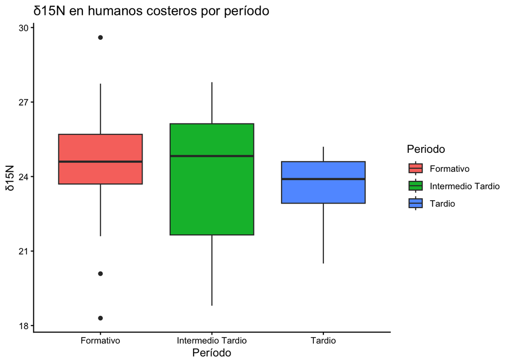

```r
ggplot(data = dieta_costa, aes(x = Periodo, y = d15N, fill = Periodo)) +
  geom_boxplot() +
  labs(x = "Período", y = "δ15N", title = "δ15N en humanos costeros por período") +
  theme_classic()
```

##### **5.2. Test de normalidad Shapiro-Wilk.**

```r
shapiro.test(dieta_costa$d15N)
```

```
##
##  Shapiro-Wilk normality test
##
## data:  dieta_costa$d15N
## W = 0.9802, p-value = 0.07437
```

Los datos distribuyen normal (al límite). Tenemos tres grupos, por lo que procedemos con ANOVA.

##### **5.3. ANOVA y test post hoc de Tukey.**

```r
anova_dieta <- aov(d15N ~ Periodo, data = dieta_costa)
summary(anova_dieta)
```

```
##              Df Sum Sq Mean Sq F value Pr(>F)
## Periodo       2   18.1   9.034    2.46 0.0898 .
## Residuals   117  429.6   3.672
## ---
## Signif. codes:  0 '***' 0.001 '**' 0.01 '*' 0.05 '.' 0.1 ' ' 1
```

```r
TukeyHSD(anova_dieta)
```

```
##   Tukey multiple comparisons of means
##     95% family-wise confidence level
##
## Fit: aov(formula = d15N ~ Periodo, data = dieta_costa)
##
## $Periodo
##                                   diff       lwr       upr     p adj
## Intermedio Tardio-Formativo -0.5356543 -1.561572 0.4902634 0.4324609
## Tardio-Formativo            -0.9407033 -1.993961 0.1125549 0.0901249
## Tardio-Intermedio Tardio    -0.4050490 -1.643933 0.8338354 0.7183793
```

##### **5.4. Interpretación.**

¿Podemos rechazar la hipótesis nula? ¿Existen diferencias significativas entre los períodos? ¿Qué nos indica esto sobre las dietas costeras a lo largo del tiempo?

#### **6. Ejercicio 4: Largo de aleta en Palmer Penguins.**

Evaluamos si existen diferencias en el largo de aleta entre las tres especies de pingüinos.

##### **6.1. Explorar los datos.**

```r
penguins
```

```
## # A tibble: 344 × 8
##    species island    bill_length_mm bill_depth_mm flipper_length_mm body_mass_g
##    <fct>   <fct>              <dbl>         <dbl>             <int>       <int>
##  1 Adelie  Torgersen           39.1          18.7               181        3750
##  2 Adelie  Torgersen           39.5          17.4               186        3800
##  3 Adelie  Torgersen           40.3          18                 195        3250
##  4 Adelie  Torgersen           NA            NA                  NA          NA
##  5 Adelie  Torgersen           36.7          19.3               193        3450
##  6 Adelie  Torgersen           39.3          20.6               190        3650
##  7 Adelie  Torgersen           38.9          17.8               181        3625
##  8 Adelie  Torgersen           39.2          19.6               195        4675
##  9 Adelie  Torgersen           34.1          18.1               193        3475
## 10 Adelie  Torgersen           42            20.2               190        4250
## # ℹ 334 more rows
## # ℹ 2 more variables: sex <fct>, year <int>
```

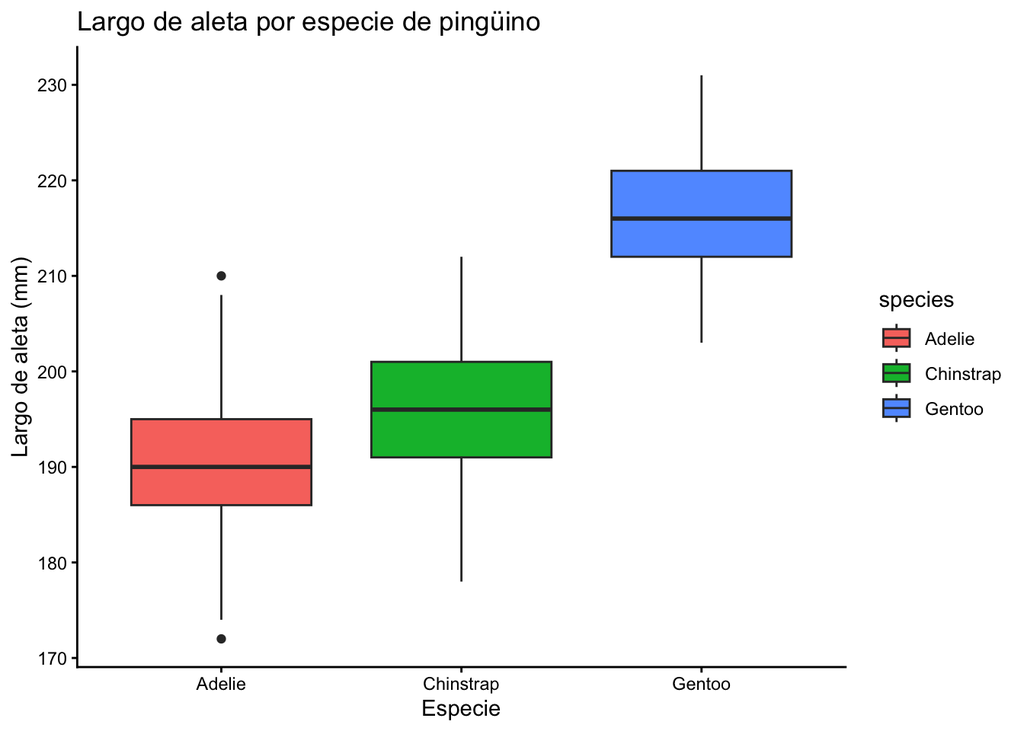

```r
ggplot(data = penguins, aes(x = species, y = flipper_length_mm, fill = species)) +
  geom_boxplot() +
  labs(x = "Especie", y = "Largo de aleta (mm)", title = "Largo de aleta por especie de pingüino") +
  theme_classic()
```

##### **6.2. Test de normalidad Shapiro-Wilk.**

```r
shapiro.test(penguins$flipper_length_mm)
```

```
##
##  Shapiro-Wilk normality test
##
## data:  penguins$flipper_length_mm
## W = 0.95155, p-value = 3.54e-09
```

El valor p es menor a 0.05, por lo que los datos **no** distribuyen normal. Tenemos tres grupos, por lo que usamos el test no paramétrico **Kruskal-Wallis**.

##### **6.3. Test de Kruskal-Wallis.**

```r
kruskal.test(flipper_length_mm ~ species, data = penguins)
```

```
##
##  Kruskal-Wallis rank sum test
##
## data:  flipper_length_mm by species
## Kruskal-Wallis chi-squared = 244.89, df = 2, p-value < 2.2e-16
```

##### **6.4. Test post hoc de Dunn.**

Al igual que ANOVA necesita Tukey, Kruskal-Wallis necesita un post hoc para saber específicamente entre qué grupos existen diferencias. Usamos el test de Dunn.

```r
dunn.test(penguins$flipper_length_mm, penguins$species)
```

```
##   Kruskal-Wallis rank sum test
##
## data: x and group
## Kruskal-Wallis chi-squared = 244.8905, df = 2, p-value = 0
##
##
##                    Dunn's Pairwise Comparison of x by group
##                                 (No adjustment)
## Col Mean-│
## Row Mean │     Adelie   Chinstra
## ─────────┼──────────────────────
## Chinstra │  -3.629336
##          │     0.0001*
##          │
##   Gentoo │  -15.47661  -8.931938
##          │     0.0000*    0.0000*
##
## α = 0.05
## Reject Ho if p ≤ α/2, where p = Pr(Z ≥ |z|)
```

##### **6.5. Interpretación.**

¿Podemos rechazar la hipótesis nula? ¿Entre qué especies existen diferencias significativas en el largo de aleta?

#### **7. Trabajo en Clases 9.**

Recuerde que siempre debe explorar sus datos con un boxplot antes de realizar cualquier análisis, y evaluar la normalidad con Shapiro-Wilk antes de elegir el test.

Para esta actividad utilizaremos las bases de datos `Diametro_vertebra_pescado.xlsx`, `Triangulo.xlsx`, y las bases de datos `palmerpenguins` e `iris` incluidas en R.

```r
vertebras <- read_excel("~/Desktop/work/0_Cuantitativa_2026/ANT305Q-2026/Clases/Clase9/Diametro_vertebra_pescado.xlsx")
vertebras
```

```
## # A tibble: 40 × 2
##    Sitio       Diametro
##    <chr>          <dbl>
##  1 Tiliviche1B     2.03
##  2 Tiliviche1B     2.28
##  3 Tiliviche1B     7.8
##  4 Tiliviche1B     2.18
##  5 Tiliviche1B     1.9
##  6 Tiliviche1B     1.82
##  7 Tiliviche1B     2.09
##  8 Tiliviche1B     2.12
##  9 Tiliviche1B     2.15
## 10 Tiliviche1B     2.45
## # ℹ 30 more rows
```

```r
triangulo <- read_excel("~/Desktop/work/0_Cuantitativa_2026/ANT305Q-2026/Clases/Clase9/Triangulo.xlsx")
triangulo
```

```
## # A tibble: 39 × 2
##    Sexo    Area
##    <chr>  <dbl>
##  1 Hombre  494.
##  2 Hombre  749.
##  3 Hombre  622.
##  4 Hombre  791.
##  5 Hombre  712.
##  6 Hombre  642.
##  7 Hombre  663.
##  8 Hombre  675.
##  9 Hombre  862.
## 10 Hombre  546.
## # ℹ 29 more rows
```

1. Analice la base de datos de diámetro de vértebras de pescado. ¿Cuántas variables hay? ¿Cuál sería su hipótesis nula? Evalúe la normalidad y elija el test correspondiente. ¿Qué puede inferir a partir de los resultados?
2. Analice la base de datos del área de triángulo mastoides. El cálculo de esta área en el cráneo humano ofrece una oportunidad para estimar el sexo en individuos prehispánicos. ¿Es posible ver una diferencia entre las áreas de triángulo mastoides entre estimaciones de sexo hombre y mujer? ¿Cuántas variables hay? ¿Cuál sería su hipótesis nula? Evalúe la normalidad y elija el test correspondiente. ¿Qué puede inferir a partir de los resultados?
3. Compare los datos de peso corporal (`body_mass_g`) de los Palmer Penguins. ¿Cuántas variables hay? ¿Cuál sería su hipótesis nula? Evalúe la normalidad y elija el test correspondiente. ¿Qué puede inferir a partir de los resultados?
4. Compare los datos de ancho de sépalo (`Sepal.Width`) de la base de datos `iris`. ¿Cuántas variables hay? ¿Cuál sería su hipótesis nula? Evalúe la normalidad y elija el test correspondiente. ¿Qué puede inferir a partir de los resultados?

← Clase Anterior Índice Siguiente Clase →